# Practical Machine Learning Course Project

Carla Risso

December 26, 2015

Using devices such as Jawbone Up, Nike FuelBand, and Fitbit it is now possible to collect a large amount of data about personal activity relatively inexpensively. One thing that people regularly do is quantify how much of a particular activity they do, but they rarely quantify how well they do it. The goal of this project is to use data from accelerometers on the belt, forearm, arm, and dumbell of 6 participants. They were asked to perform barbell lifts correctly and incorrectly in 5 different ways. More information is available from the website here: http://groupware.les.inf.puc-rio.br/har (see the section on the Weight Lifting Exercise Dataset).

## Data

The training data for this project are available here: [https://d396qusza40orc.cloudfront.net/predmachlearn/pml-training.csv]

The test data are available here: [https://d396qusza40orc.cloudfront.net/predmachlearn/pml-testing.csv]

The data for this project come from this source: [http://groupware.les.inf.puc-rio.br/har]. If you use the document you create for this class for any purpose please cite them as they have been very generous in allowing their data to be used for this kind of assignment.

## Reproducibility: R versions, packages, seed.

This report was generated with R Studio 0.99.489, R version 3.2.3. The following packages were used in this project: caret, rattle, rpart and randomForest. The pseudo-random seed was set to 1234.

```r
# Load necessary libraries
library(caret)
library(rattle)
library(rpart)
library(randomForest)

set.seed(1234)
```

## Load & clean datasets

```r
URL_training = "http://d396qusza40orc.cloudfront.net/predmachlearn/pml-training.csv"

URL_testing = "http://d396qusza40orc.cloudfront.net/predmachlearn/pml-testing.csv"


# read data into dataframes, assign NA to missing/error values
training = read.csv(url(URL_training), na.strings = c("", "#DIV/0!", "NA"))
testing = read.csv(url(URL_testing), na.strings = c("", "#DIV/0!", "NA"))
```

## Split training set into sub-training and sub-testing for cross-validation

```r
inTrain = createDataPartition(y=training$classe, p=0.8, list=FALSE)

subtrain = training[inTrain,]
subtest = training[-inTrain,]

dim(subtrain) ; dim(subtest)
```

```
## [1] 15699   160
```

```
## [1] 3923  160
```

## Cleaning the dataset

```r
# Remove first seven columns (superfluous for ML) in the "subtrain" dataset.

subtrain = subtrain[,-c(1:7)]

# Some of the numeric variables have too many NAs. I'm removing those with > 60 % of NAs.

del = apply(subtrain, 2, function(x) sum(is.na(x)))/nrow(subtrain)

subtrain = subtrain[!(del>0.60)]

dim(subtrain)
```

```
## [1] 15699    53
```

```r
# Run the same transformations in the subtest dataset (cross-validation):

reduced_cols = colnames(subtrain)
subtest = subtest[reduced_cols]

# check dimensions
dim(subtest)
```

```
## [1] 3923   53
```

## Apply Machine Learning algorithms

### CART model using the caret package

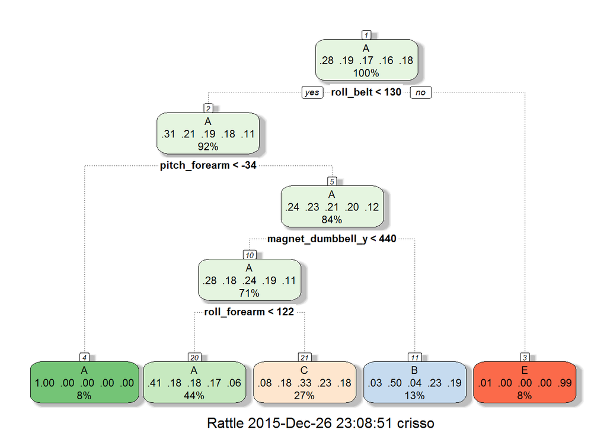

```r
# fit model using the caret package with method rpart
CARTmod = train(classe~., method = "rpart", data=subtrain)

fancyRpartPlot(CARTmod$finalModel)
```

```r
# predicting on the subtest (cross-validation)

predictCART = predict(CARTmod, newdata = subtest)

confusionMatrix(predictCART, subtest$classe)
```

```
## Confusion Matrix and Statistics
##
##           Reference
## Prediction    A    B    C    D    E
##          A 1025  310  325  290  115
##          B   20  271   23  102   95
##          C   69  178  336  251  184
##          D    0    0    0    0    0
##          E    2    0    0    0  327
##
## Overall Statistics
##
##                Accuracy : 0.4994
##                  95% CI : (0.4836, 0.5151)
##     No Information Rate : 0.2845
##     P-Value [Acc > NIR] : < 2.2e-16
##
##                   Kappa : 0.3451
##  Mcnemar's Test P-Value : NA
##
## Statistics by Class:
##
##                      Class: A Class: B Class: C Class: D Class: E
## Sensitivity            0.9185  0.35705  0.49123   0.0000  0.45354
## Specificity            0.6295  0.92415  0.78944   1.0000  0.99938
## Pos Pred Value         0.4964  0.53033  0.33006      NaN  0.99392
## Neg Pred Value         0.9510  0.85698  0.88021   0.8361  0.89037
## Prevalence             0.2845  0.19347  0.17436   0.1639  0.18379
## Detection Rate         0.2613  0.06908  0.08565   0.0000  0.08335
## Detection Prevalence   0.5264  0.13026  0.25950   0.0000  0.08386
## Balanced Accuracy      0.7740  0.64060  0.64033   0.5000  0.72646
```

### Random Forest approach

```r
# fit a model using the randomForest package.

rfmod = randomForest(classe~., data=subtrain)

# predicting with sub-test (cross-validation)
predictrf = predict(rfmod, newdata = subtest)

# calculating out-of-sample error
confusionMatrix(predictrf, subtest$classe)
```

```
## Confusion Matrix and Statistics
##
##           Reference
## Prediction    A    B    C    D    E
##          A 1116    3    0    0    0
##          B    0  755    5    0    0
##          C    0    1  679    1    0
##          D    0    0    0  642    0
##          E    0    0    0    0  721
##
## Overall Statistics
##
##                Accuracy : 0.9975
##                  95% CI : (0.9953, 0.9988)
##     No Information Rate : 0.2845
##     P-Value [Acc > NIR] : < 2.2e-16
##
##                   Kappa : 0.9968
##  Mcnemar's Test P-Value : NA
##
## Statistics by Class:
##
##                      Class: A Class: B Class: C Class: D Class: E
## Sensitivity            1.0000   0.9947   0.9927   0.9984   1.0000
## Specificity            0.9989   0.9984   0.9994   1.0000   1.0000
## Pos Pred Value         0.9973   0.9934   0.9971   1.0000   1.0000
## Neg Pred Value         1.0000   0.9987   0.9985   0.9997   1.0000
## Prevalence             0.2845   0.1935   0.1744   0.1639   0.1838
## Detection Rate         0.2845   0.1925   0.1731   0.1637   0.1838
## Detection Prevalence   0.2852   0.1937   0.1736   0.1637   0.1838
## Balanced Accuracy      0.9995   0.9966   0.9960   0.9992   1.0000
```

## Generating answers for submission

```r
# generating answers

answers = predict(rfmod, testing)

pml_write_files = function(x){
  n = length(x)
  for(i in 1:n){
    filename = paste0("problem_id_",i,".txt")
    write.table(x[i],file=filename,quote=FALSE,row.names=FALSE,col.names=FALSE)
  }
}

pml_write_files(answers)
```

## Discussion

This dataset consisted of 19622 observations. 80% of these observations were used to build a predictive algorithm, and the rest were used for cross-validation and to estimate out-of-sample error. Prior to applying any training model, the data ware cleaned by removing superflouos features and numerical variables with over 60% NA values.

Despite the high quality of this algorithm, it is worth mentioning that its predictive power may be restricted to observations that are similar in nature to those used to build the model. The data used here was collected only for a certain type of individuals under very specific conditions. The validity of this model for a more general population remains undetermined.